# IF_analysis

2024-07-26

## Adding packages

```r
library(readxl)
library(ggplot2)
library(tidyverse)
library(lubridate)
library(RColorBrewer)
```

## Statistical analyses

```r
#various packages related to mixed modelling
library(lme4)
library(nlme)
library(lattice)
library(effects)
library(emmeans)
library(car)
```

## Amy setwd and upload data

```r
#setwd("C:/Users/amyh/Documents/R_data/2024_internships")
#taxa <- read.csv("Troy_data2.csv")
#water_quality <- read.csv("Troy_data.csv")
```

## Datasets, Palettes

Reading in the data sets, and set up colorblind-friendly color palette(s)

```r
taxa <- read_excel("~/Desktop/Iron Floc UA Project/iron_floc_impact_on_macroinvertebrate_biodiversity_taxa.xlsx")

water_quality <- read_excel("~/Desktop/Iron Floc UA Project/iron_floc_impact_on_macroinvertebrate_biodiversity_water_quality.xlsx",
    sheet = "data")

cbPalette <- c("#999999", "#E69F00", "#56B4E9", "#009E73", "#F0E442", "#0072B2", "#D55E00", "#CC79A7")
```

## Data Formats

If you are getting errors and the syntax/et are correct, check what type of data the colum is, and run an as.DATATYPE if it’s the wrong kind of data for what you’re trying to do.

```r
str(taxa)
```

```
## tibble [654 × 7] (S3: tbl_df/tbl/data.frame)
##  $ taxa           : chr [1:654] "diptera atherix" "diptera atherix" "diptera atherix" "diptera atherix" ...
##  $ site_name      : chr [1:654] "j3" "j3" "j3" "j3" ...
##  $ transect_number: num [1:654] 1 1 1 1 1 1 1 1 1 1 ...
##  $ condition      : chr [1:654] "restored" "restored" "restored" "restored" ...
##  $ date           : POSIXct[1:654], format: "2024-07-09" "2024-07-09" ...
##  $ sample         : chr [1:654] "yes" "yes" "yes" "yes" ...
##  $ analogue       : num [1:654] 1 1 1 1 1 1 1 1 1 1 ...
```

```r
str(water_quality)
```

```
## tibble [54 × 15] (S3: tbl_df/tbl/data.frame)
##  $ site_name      : chr [1:54] "j3" "j3" "j3" "j3" ...
##  $ transect_number: num [1:54] 1 1 1 2 2 2 3 3 3 1 ...
##  $ plot_location  : chr [1:54] "down" "at" "up" "down" ...
##  $ ferrous_iron   : num [1:54] 10 10 5 15 15 15 2.5 5 5 5 ...
##  $ d_o            : num [1:54] 3.3 3.4 3.8 4 3 2.2 3.1 3.3 3.2 5.5 ...
##  $ d_o%           : num [1:54] 0.43 0.44 0.48 0.49 0.37 0.27 0.39 0.31 0.4 0.64 ...
##  $ conductivity   : num [1:54] 495 519 506 518 522 538 518 520 519 11.3 ...
##  $ temp           : num [1:54] 27.4 27.4 27.5 25.6 25.7 25 26.5 27.1 27.3 22.7 ...
##  $ turbidity      : num [1:54] 22 28 36.5 20.5 46 ...
##  $ percent_cover  : chr [1:54] "na" "0.28299999999999997" "na" "na" ...
##  $ date           : POSIXct[1:54], format: "2024-07-09" "2024-07-09" ...
##  $ flow_rate      : num [1:54] 0.00894 0.00894 0.00894 0.00894 0.00894 0.00894 0.00894 0.00894 0.00894 0.00294 ...
##  $ analogue       : num [1:54] 1 1 1 1 1 1 1 1 1 2 ...
##  $ condition      : chr [1:54] "restored" "restored" "restored" "restored" ...
##  $ geo_order      : num [1:54] 9 8 7 6 5 4 3 2 1 9 ...
```

## Creating the Environment

Create the all_sites dataframe to summarize the site_name, analogue, number of species, number of individuals, biodiversity/species richness percent, and mean iron floc coverage percent.

```r
prcnt_cvr <- water_quality %>%
  group_by(site_name, condition) %>%
  summarize(mean_cover=mean(as.numeric(percent_cover), na.rm = TRUE), flow=mean(as.numeric(flow_rate)), ferrous_iron=mean(as.numeric(ferrous_iron)))
##this created all_sites, if you need to summarize the total number of unique/total number of entries
all_sites <- taxa %>% group_by(site_name, analogue) %>%
  ##select(site_name, taxa) %>% not necesary, try if there are errors
  summarize(count_taxa=n_distinct(taxa), total=n()) %>%
  mutate(biodiversity=count_taxa/total)
##adds the biodiversity values

sum_sites <- merge(prcnt_cvr, all_sites)
```

## Question 1

Does stream restoration increase the presence of iron flocculate by creating low-flow, acidic, and high iron water conditions compared to unrestored streams? -%cover -flow_rate -ferrous-iron x-condition

AMY: Additional Data manipulation/exploration 1. Percent Cover in restored/unrestored

```r
#only using "at" plot locations
water_quality1 <- water_quality %>%
  filter(plot_location == "at")

water_quality1 <- as.data.frame(water_quality1)

#percent cover from non-numeric to numeric
water_quality1$percent_cover <- as.numeric(water_quality1$percent_cover)

#BarGraphStats for calculating means
barGraphStats <- function(data, variable, byFactorNames) {
  count <- length(byFactorNames)
  N <- aggregate(data[[variable]], data[byFactorNames], FUN=length)
  names(N)[1:count] <- byFactorNames
  names(N) <- sub("^x$", "N", names(N))
  mean <- aggregate(data[[variable]], data[byFactorNames], FUN=mean)
  names(mean)[1:count] <- byFactorNames
  names(mean) <- sub("^x$", "mean", names(mean))
  sd <- aggregate(data[[variable]], data[byFactorNames], FUN=sd)
  names(sd)[1:count] <- byFactorNames
  names(sd) <- sub("^x$", "sd", names(sd))
  preSummaryStats <- merge(N, mean, by=byFactorNames)
  finalSummaryStats <- merge(preSummaryStats, sd, by=byFactorNames)
  finalSummaryStats$se <- finalSummaryStats$sd / sqrt(finalSummaryStats$N)
  return(finalSummaryStats)
}

#ggplot(g1 <- ggplot(data = barGraphStats(data = water_quality1, variable = "percent_cover", byFactorNames = c("site_name")), aes(x=site_name, y=mean)) +
    #geom_bar(stat='identity', position=position_dodge(), width=0.8) +
    #geom_errorbar(aes(ymin=mean-se, ymax=mean+se), width = 0.2, position = position_dodge(0.9)) +
    #annotate("text", x = 1, y = 2.7 , label = "a", size = 8)+
    #annotate("text", x = 2, y = 2.7 , label = "a", size = 8)+
    #annotate("text", x = 3, y = 1.75, label = "b", size = 8) +
   #theme(legend.position = "none") + xlab("Restoration") + ylab("Percent Cover"))
```

Q1 Graphs Percent cover, dissolved iron, and flow rate against site name filled by condition

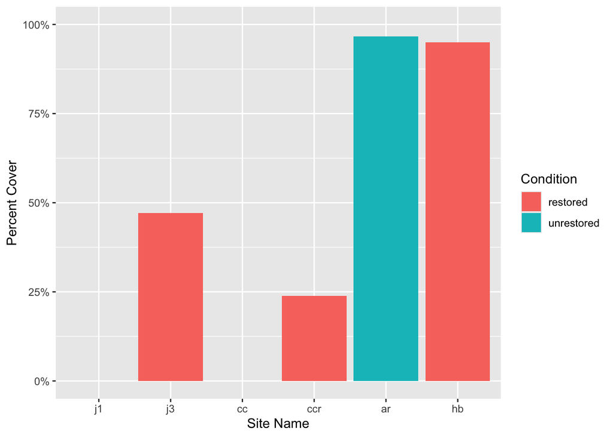

```r
ggplot(sum_sites, aes(x=factor(site_name), y=mean_cover, fill=factor(condition)))+
  geom_bar(stat="identity")+
  #geom_text(aes(label=mean_cover), vjust=-1)+
  scale_x_discrete(limits = c("j1", "j3", "cc", "ccr", "ar", "hb"))+
  scale_y_continuous(labels=scales::percent, limits=c(0, 1))+
  labs(x="Site Name", y="Percent Cover", fill="Condition")
```

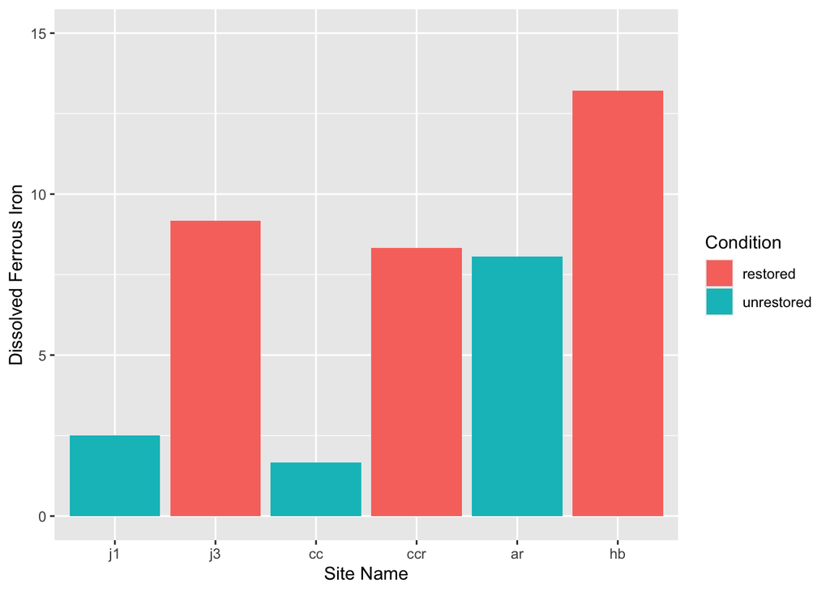

```r
ggplot(sum_sites, aes(x=factor(site_name), y=ferrous_iron, fill=factor(condition)))+
  geom_bar(stat="identity")+
  #geom_text(aes(label=ferrous_iron), vjust=-1)+
  scale_x_discrete(limits = c("j1", "j3", "cc", "ccr", "ar", "hb"))+
  scale_y_continuous(limits=c(0, 15))+
  labs(x="Site Name", y="Dissolved Ferrous Iron", fill="Condition")
```

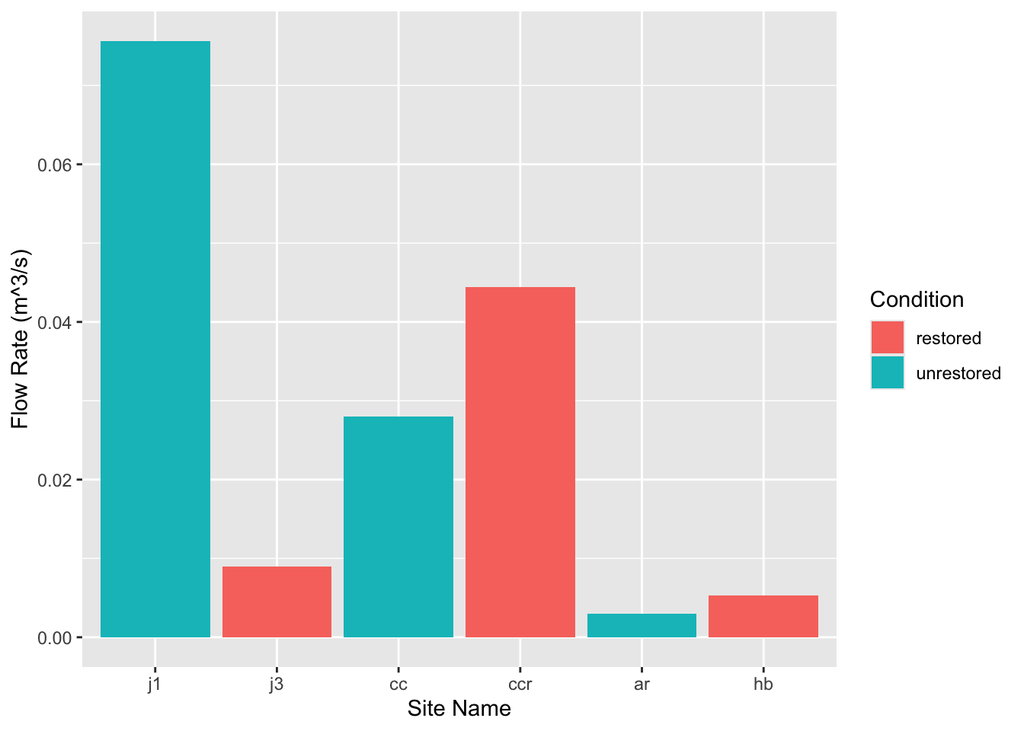

```r
ggplot(sum_sites, aes(x=factor(site_name), y=flow, fill=factor(condition)))+
  geom_bar(stat="identity")+
  #geom_text(aes(label=mean_cover), vjust=-1)+
  scale_x_discrete(limits = c("j1", "j3", "cc", "ccr", "ar", "hb"))+
  #scale_y_continuous(labels=scales::percent, limits=c(0, 1))+
  labs(x="Site Name", y="Flow Rate (m^3/s)", fill="Condition")
```

## Question 2

How does iron flocculate affect the diversity and abundance of macroinvertebrates?

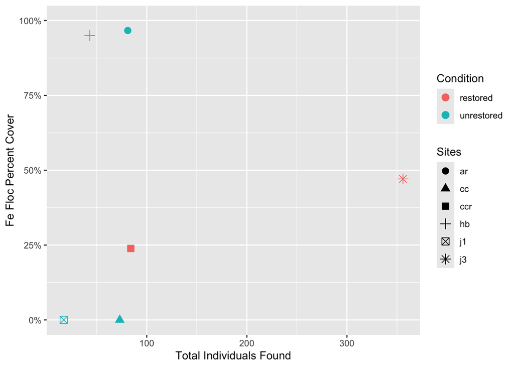

```r
ggplot(sum_sites, aes(x=total, y=mean_cover))+
  geom_point(aes(color=condition, shape=site_name), size=3)+
  scale_y_continuous(limits=c(0, 1), labels=scales::percent)+
  labs(x="Total Individuals Found", y="Fe Floc Percent Cover", color="Condition", shape="Sites")
```

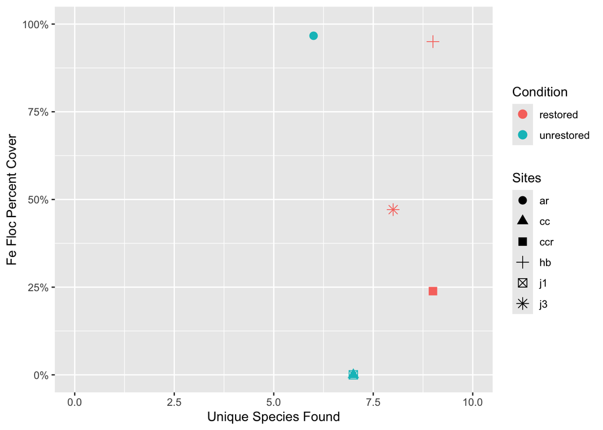

```r
ggplot(sum_sites, aes(x=count_taxa, y=mean_cover))+
  geom_point(aes(color=condition, shape=site_name), size=3)+
  scale_y_continuous(limits=c(0, 1), labels=scales::percent)+
  scale_x_continuous(limits=c(0, 10))+
  labs(x="Unique Species Found", y="Fe Floc Percent Cover", color="Condition", shape="Sites")
```

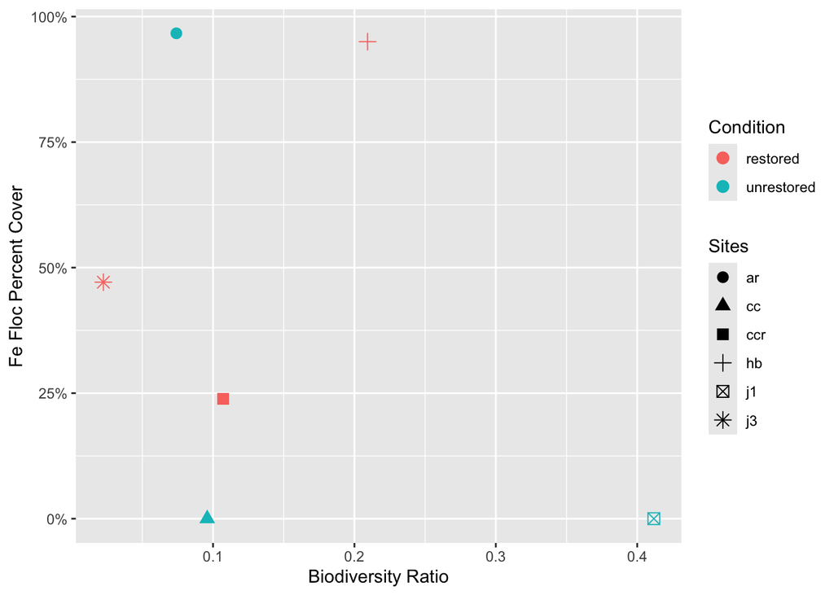

```r
ggplot(sum_sites, aes(x=biodiversity, y=mean_cover))+
  geom_point(aes(color=condition, shape=site_name), size=3)+
  scale_y_continuous(labels=scales::percent)+
  labs(x="Biodiversity Ratio", y="Fe Floc Percent Cover", color="Condition", shape="Sites")
```

## Question 3

Does the effect of iron flocculate on the abundance and diversity of macroinvertebrates depend on if a stream has been restored?

Plot the biodiversity, #of species, and #of individuals against site names, filled by condition

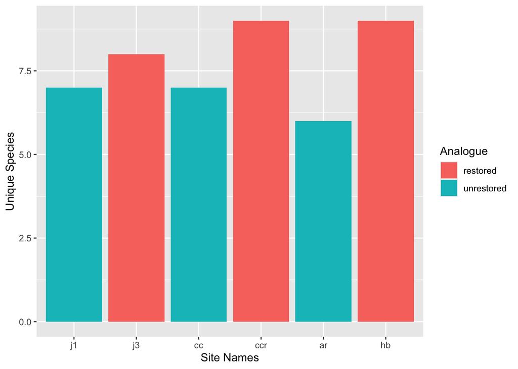

```r
ggplot(sum_sites, aes(x=factor(site_name), y=count_taxa, fill=factor(condition)))+
  geom_bar(stat="identity")+
  scale_x_discrete(limits=c("j1", "j3", "cc", "ccr", "ar", "hb"))+
  labs(x="Site Names", y="Unique Species", fill="Analogue")
```

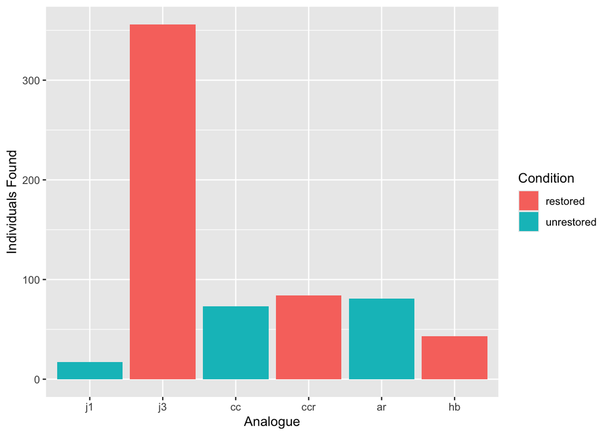

```r
ggplot(sum_sites, aes(x=factor(site_name), y=total, fill=factor(condition)))+
  geom_bar(stat="identity")+
  scale_x_discrete(limits=c("j1", "j3", "cc", "ccr", "ar", "hb"))+
  labs(x="Analogue", y="Individuals Found", fill="Condition")
```

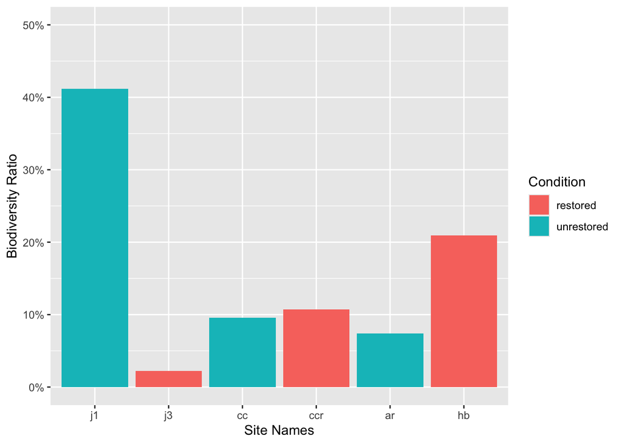

```r
ggplot(sum_sites, aes(x=factor(site_name), y=biodiversity, fill=factor(condition)))+
  geom_bar(stat = "identity")+
  scale_x_discrete(limits=c("j1", "j3", "cc", "ccr", "ar", "hb"))+
  scale_y_continuous(labels=scales::percent, limits=c(0, 0.5))+
  labs(x="Site Names", y="Biodiversity Ratio", fill="Condition")
```

## Data Along Streams

Using a scatterplot to show the water quality levels within a stream with the position on the X axis

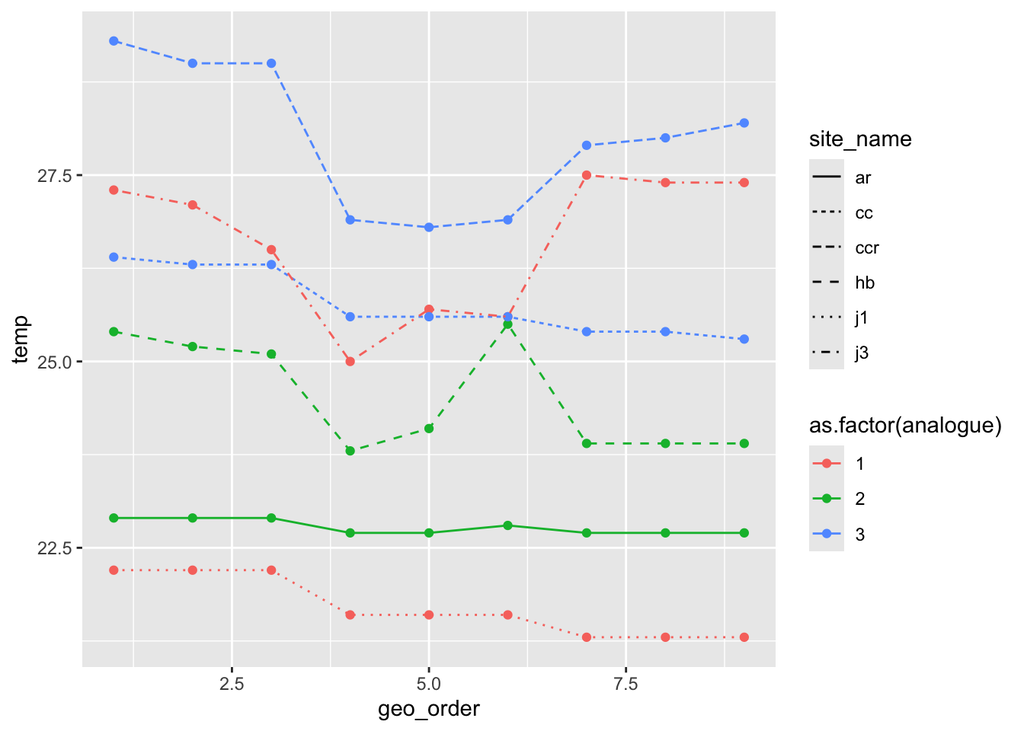

```r
ggplot(water_quality, aes(x=geo_order, y=temp, color=as.factor(analogue)))+
         geom_point()+
  geom_line(aes(linetype=site_name))
```

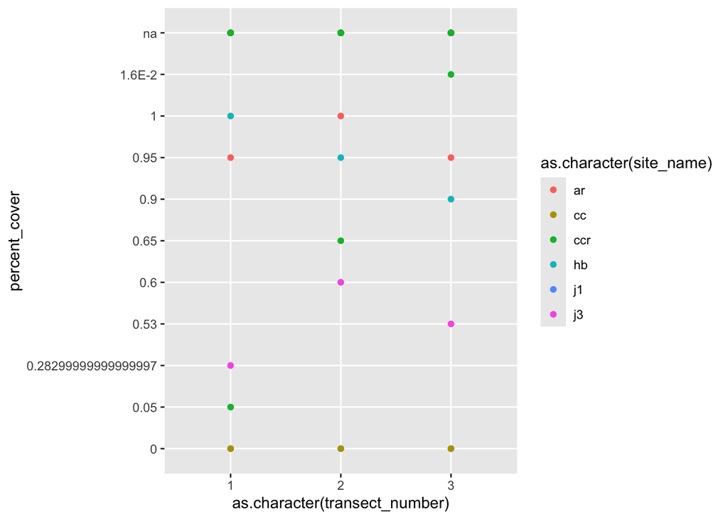

```r
#  geom_text()

#ggplot(water_quality, aes(x=geo_order, y=d_o, color=analogue))+
#         geom_point()+
#  geom_line(aes(linetype=site_name))

#ggplot(water_quality, aes(x=geo_order, y=`d_o%`, color=analogue))+
#         geom_point()+
#  geom_line(aes(linetype=site_name))

#ggplot(water_quality, aes(x=geo_order, y=turbidity, color=as.character(site_name)))+
#         geom_point()+
#  geom_line(aes(linetype=as.character(analogue)))+
#  geom_vline(xintercept=c(3.5, 6.5))+
#  scale_x_continuous(breaks=NULL)+
#  labs(x="Sequential Data along Streams", y="Turbidity (cm)", color="site_name", linetype="analogue")+
#  scale_fill_manual(values=cbPalette)
## find a way to krump down on the top of the graph to cut off anything above 120cm

ggplot(water_quality, aes(x=as.character(transect_number), y=percent_cover, color=as.character(site_name), na.rm=TRUE))+
  geom_point()
```

```r
# can I make it such that I have a geom_line(aes(y=percent_cover)) for each individual site name?

# change this so that color maps to the analogue, linetype to analogue, and *the lines are labled with the site names directly on the graph*
```

## Amy’s code chunk

```r
barGraphStats <- function(data, variable, byFactorNames) {
  count <- length(byFactorNames)
  N <- aggregate(data[[variable]], data[byFactorNames], FUN=length)
  names(N)[1:count] <- byFactorNames
  names(N) <- sub("^x$", "N", names(N))
  mean <- aggregate(data[[variable]], data[byFactorNames], FUN=mean)
  names(mean)[1:count] <- byFactorNames
  names(mean) <- sub("^x$", "mean", names(mean))
  sd <- aggregate(data[[variable]], data[byFactorNames], FUN=sd)
  names(sd)[1:count] <- byFactorNames
  names(sd) <- sub("^x$", "sd", names(sd))
  preSummaryStats <- merge(N, mean, by=byFactorNames)
  finalSummaryStats <- merge(preSummaryStats, sd, by=byFactorNames)
  finalSummaryStats$se <- finalSummaryStats$sd / sqrt(finalSummaryStats$N)
  return(finalSummaryStats)

  ggplot(data = barGraphStats(data = damage2, variable = "herbivore", byFactorNames = c("Area_type")), aes(x=Area_type, y=mean, fill=Area_type)) +
   geom_bar(stat='identity', position=position_dodge()) +
    geom_errorbar(aes(ymin=mean-se, ymax=mean+se), width = 0.2, position = position_dodge(0.9))
}
```